# Análise das alterações feitas pelos usuários no github

Bruno Rafael

20 de maio de 2017

Para esta pesquisa, foram avaliados os dados do github conforme o número de alterações diárias feitas pelos usuários. Todo o trablaho foi feito em torno de uma amostra dos dados. Os dados usados estão neste [link](https://raw.githubusercontent.com/nazareno/fpcc2/master/datasets/github-users-committing-filetypes.csv) e todo o projeto de desenvolvimento se encontra no github e podem ser encontrados [aqui](https://github.com/BrunoRafael/FPCC)

Os dados contém 5 parâmetros para análise e são eles:

File_extension: A extensão do arquivo modificado; month_day : Dia do mês em que a alteração foi feita; the_month : Mês em que a alteração foi feita; the_year : Ano em que a alteração foi feita; users : Número de usuários que alteraram determinado tipo de arquivo em uma determinada data do ano

A amostra foi coletada nos últimos dois anos, que correspondem a 2016 e parte de 2017.

## Introdução

Esta pesquisa busca analisar arquivos com extensão .js e .java que são que correspondem a duas linguagens que estão bastante em alta no mercado de software, que são respectivamente as linguagens javascript usada para aplicações cliente que executam nos browsers e java muito usada em servidores.Além de java e javascript, há também dados de arquivos que não correspondem a nenhuma linguagem de programação como png e pdf por exemplo.

Conforme o gráfico da figura 1, os arquivos que mais possuem alterações no git, são arquivos com extensão md. Estes arquivos são extensões do RMarkdown que é um pacote usado com a linguagem R para formatação de documentos para visualização de resultados de pesquisas usando o R. Os arquivos .js são o segundo mais modificado.

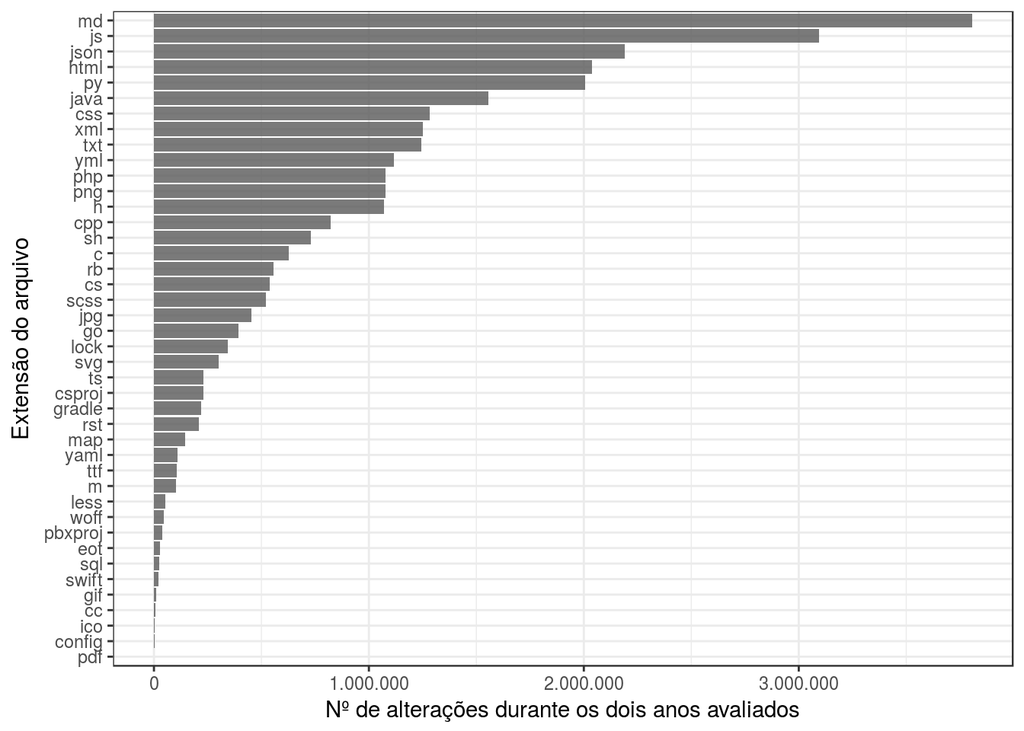

Figura 1 - Frequência de acesso por arquivo

```r
git_data %>% group_by(file_extension) %>%
summarise(sum = sum(users)) %>%
ggplot(aes(x = reorder(as.factor(file_extension), sum), y = sum)) +
geom_histogram(stat = "identity", alpha=0.8) +
labs(x="Extensão do arquivo", y = "Nº de alterações durante os dois anos avaliados")+
scale_y_continuous(labels = formata_label)+
coord_flip()
```

Para isso, é necessário selecionar apenas as informações referentes a estas linguagens. Portanto, os dados selecionados nesta pesquisa contém apenas informações das linguagens java e javascript.

Esta pesquisa busca responder as seguintes perguntas:

Há uma diferença significativa na popularidade das liguagens durante a semana e durante o fim de semana?

Existe uma diferença significativa na variação da popularidade das duas quando você compara o quanto a popularidade de cada uma varia durante os dias da semana?

É necessário antes de tudodar uma olhada nos dados e saber como se distribuem e quais os valores limites para cada parâmetro.

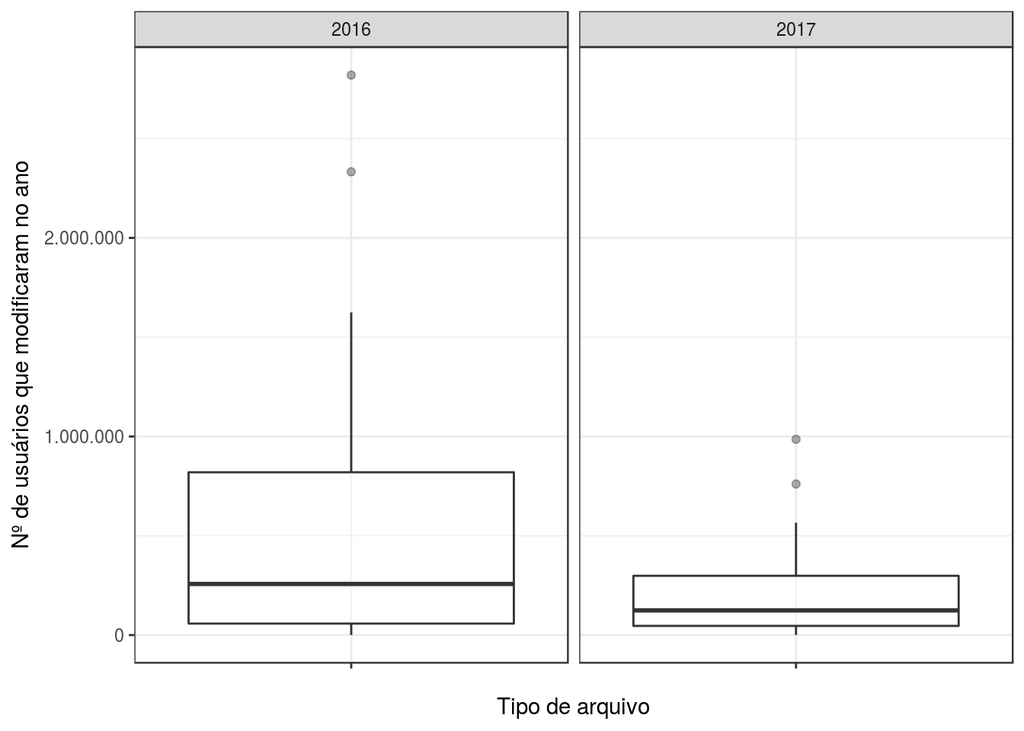

Figura 2 - Distribuições do número de acesso

```r
git_data %>%
  group_by(file_extension, the_year) %>%
  summarise(sum = sum(users)) %>%
  arrange(desc(sum)) %>%
  ggplot(aes(x = "", y = sum)) +
  geom_boxplot(alpha = 0.4)+
  facet_grid(.~the_year) +
  scale_y_continuous(labels = formata_label)+
  labs(x = "Tipo de arquivo", y = "Nº de usuários que modificaram no ano")
```

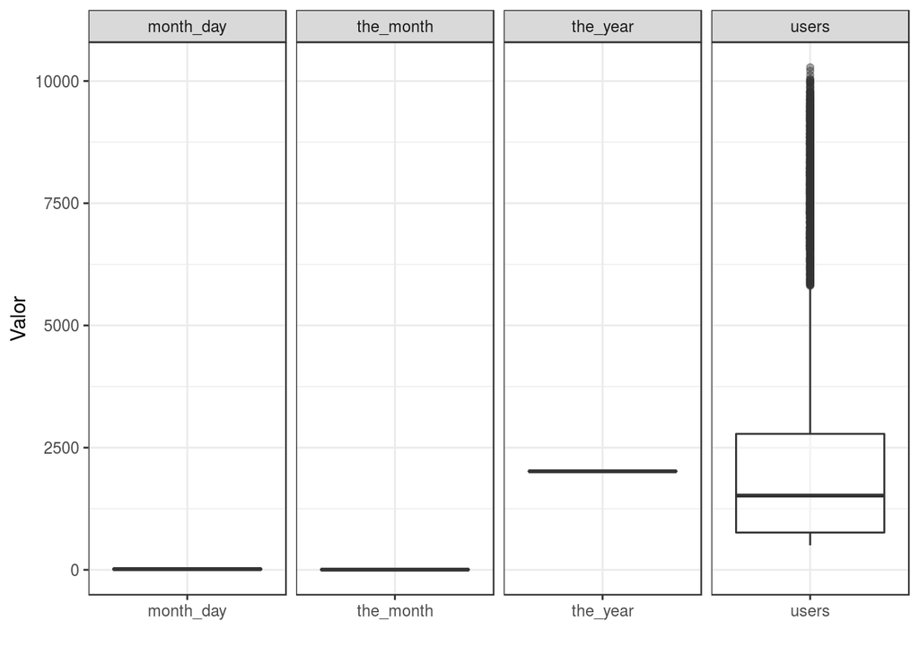

```r
dados_capes_change_column_names <- git_data %>%
    gather(key = "variavel", value = "valor", `month_day`, `the_month`, `the_year`, `users`)

dados_capes_change_column_names %>%
    ggplot(aes(y = valor, x =variavel, group=variavel)) +
    geom_boxplot(alpha = 0.4)+
    facet_grid(.~variavel, scales = "free_x")+
    labs(x="", y = "Valor")
```

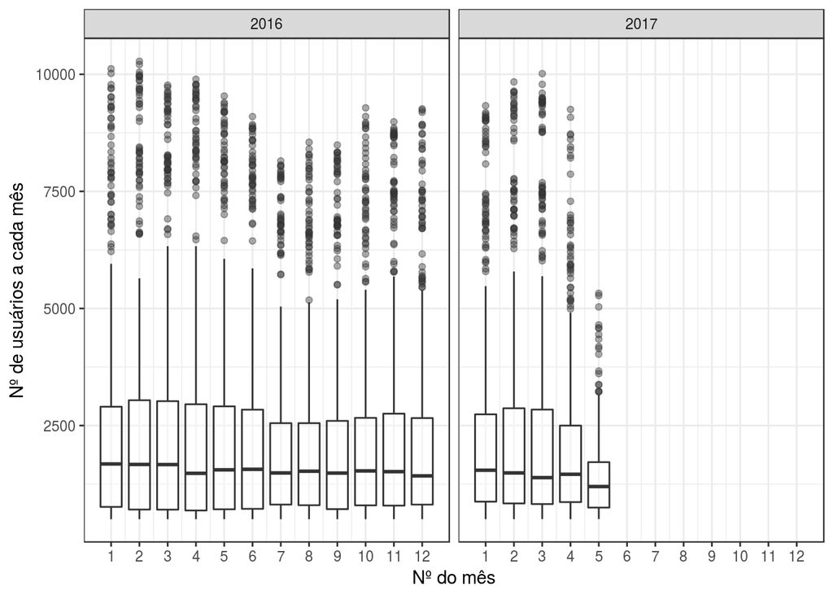

```r
git_data %>%
  group_by(the_year, the_month, users) %>%
  arrange(desc(users)) %>%
  ggplot(aes(x = the_month, y = users, group=the_month)) +
  geom_boxplot(alpha = 0.4)+
  facet_grid(.~the_year) +
  scale_x_continuous(breaks=unique(git_data$the_month))+
  labs(x = "Nº do mês", y = "Nº de usuários a cada mês")
```